# NOAA Storm Analysis - Health and Economic Outcomes

Paul Selling

7/15/2020

# Executive Summary

This analysis seeks to provide insight into which weather events results in the worst population health and the worst economic outcomes. The dataset we used is from the NOAA’s storm database. Tornados result in the worst population health outcomes. Floods result in the worst economic outcomes.

# Data processing

First, we load in the data and the libraries we need for this analysis. The `read.csv` function is able to decompress the .csv.bz2 file, so that is all we need to load in the data. Since this is a very large dataset, we can cache the dataset to ensure we only need to load it once. We’ll also reduce the dataframe to only the columns we’ll care about in this analysis to improve performance elsewhere.

```r
#load in the libraries
library(ggplot2)
library(dplyr)
library(stringdist)

#load in the data
data <- read.csv(".\\repdata_data_StormData.csv.bz2",header=TRUE)

#Get names of columns
names(data)
```

```
##  [1] "STATE__"    "BGN_DATE"   "BGN_TIME"   "TIME_ZONE"  "COUNTY"
##  [6] "COUNTYNAME" "STATE"      "EVTYPE"     "BGN_RANGE"  "BGN_AZI"
## [11] "BGN_LOCATI" "END_DATE"   "END_TIME"   "COUNTY_END" "COUNTYENDN"
## [16] "END_RANGE"  "END_AZI"    "END_LOCATI" "LENGTH"     "WIDTH"
## [21] "F"          "MAG"        "FATALITIES" "INJURIES"   "PROPDMG"
## [26] "PROPDMGEXP" "CROPDMG"    "CROPDMGEXP" "WFO"        "STATEOFFIC"
## [31] "ZONENAMES"  "LATITUDE"   "LONGITUDE"  "LATITUDE_E" "LONGITUDE_"
## [36] "REMARKS"    "REFNUM"
```

After some looking at the names of the columns in our dataset, it looks like the columns we are interested in are `EVTYPE`, `FATALITIES`, `INJURIES`, `PROPDMG`, `CROPDMG`, `PROPDMGEXP`, and `CROPDMGEXP`. Lets extract that into a smaller dataset.

```r
reducedData <- data[c("BGN_DATE","EVTYPE","FATALITIES","INJURIES",
                      "PROPDMG","PROPDMGEXP","CROPDMG","CROPDMGEXP")]
```

```r
reducedData$BGN_DATE <- as.Date(data$BGN_DATE, "%m/%d/%Y")
reducedData <- reducedData[reducedData$BGN_DATE>=1996,]
```

We want to sum the health impacts and economic impacts so we need to ensure all variables are numeric. We’ll also break these into two separate dataframes for health and economic outcomes. This will make cleaning up the data a bit easier. We’ll also sum up the health outcomes directly now so we don’t have to worry about that later. We can also eliminate all observations with zero combined injuries and fatalities because they have no impact on the cumulative health impact.

```r
reducedData$FATALITIES <- as.numeric(reducedData$FATALITIES)
reducedData$INJURIES <- as.numeric(reducedData$INJURIES)
reducedData$PROPDMG <- as.numeric(reducedData$PROPDMG)
reducedData$CROPDMG <- as.numeric(reducedData$CROPDMG)


healthData <- reducedData[c("EVTYPE","FATALITIES","INJURIES")]
economicData <- reducedData[c("EVTYPE","PROPDMG","PROPDMGEXP","CROPDMG","CROPDMGEXP")]

healthData["HEALTH.OUTCOMES"] <- healthData$FATALITIES + healthData$INJURIES
healthData <- healthData[healthData$HEALTH.OUTCOMES > 0,]
healthData <- healthData[c("EVTYPE","HEALTH.OUTCOMES")]
```

Now we’ll clean up the damage values by working through the exponents. Per the analysis in "[How to Handle Exponent Value of PROPDMGEXP and CROPDMGEXP"](https://rstudio-pubs-static.s3.amazonaws.com/58957_37b6723ee52b455990e149edde45e5b6.html), we know that B and b stands for billions, M and m stand for millions, K and k stand for thousands, and H and h stand for hundreds. We also know that the integers 0 through 8 all correspond to a multiple of 10. We will remove the rows where we don’t know the exponent for either the property damage or the crop damage. We’ll also remove the observations with no property or crop damage because they do not contribute to the overall economic impacts for a given weather event. We’ll also convert the damage to value in billions for consistency.

```r
economicData <- subset(economicData, (PROPDMGEXP %in% c("B","b","M","m","K","k","H","h","0",
                                                        "1","2","3","4","5","6","7","8") &
                                          CROPDMGEXP %in% c("B","b","M","m","K","k","H","h","0",
                                                        "1","2","3","4","5","6","7","8")))

economicData <- economicData[(economicData$PROPDMG + economicData$CROPDMG)>0,]

#Adjust property damage value
for(i in 1:nrow(economicData)){
    if(economicData$PROPDMGEXP[i] %in% c("0","1","2","3","4","5","6","7","8")){
        economicData$PROPDMG[i] <- economicData$PROPDMG[i]/100000000 #dividing by 100 million since
                                                                     #counted in tens
    }
    else if(economicData$PROPDMGEXP[i] %in% c("M","m")){
        economicData$PROPDMG[i] <- economicData$PROPDMG[i]/1000 #dividing by 1000 since
                                                                #counted in millions
    }
    else if (economicData$PROPDMGEXP[i] %in% c("K","k")){
        economicData$PROPDMG[i] <- economicData$PROPDMG[i]/1000000 #dividing by 1 million since
                                                                   #counted in thousands
    }

    else {
        economicData$PROPDMG[i] <- economicData$PROPDMG[i]/10000000 #dividing by 10 million since
                                                                    #counted in hundreds
    }
}

#Adjust crop damage data
for(i in 1:nrow(economicData)){
    if(economicData$CROPDMGEXP[i] %in% c("0","1","2","3","4","5","6","7","8")){
        economicData$CROPDMG[i] <- economicData$CROPDMG[i]/100000000 #dividing by 100 million since
                                                                     #counted in tens
    }
    else if(economicData$CROPDMGEXP[i] %in% c("M","m")){
        economicData$CROPDMG[i] <- economicData$CROPDMG[i]/1000 #dividing by 1000 since
                                                                #counted in millions
    }
    else if (economicData$CROPDMGEXP[i] %in% c("K","k")){
        economicData$CROPDMG[i] <- economicData$CROPDMG[i]/1000000 #dividing by 1 million since
                                                                   #counted in thousands
    }
    else {
        economicData$PROPDMG[i] <- economicData$CROPDMG[i]/10000000 #dividing by 10 million since
                                                                    #counted in hundreds
    }
}
```

```r
economicData["ECONOMIC.OUTCOMES"] <- economicData$PROPDMG + economicData$CROPDMG

economicData <- economicData[c("EVTYPE","ECONOMIC.OUTCOMES")]
```

Finally, we need to consolidate the weather events together so we’re only looking at the 48 unique types of events. From the National Weather Service’s documentation, we see the 48 unique types of events (stored directly in a list) are:

```r
events <- c("Astronomical Low Tide",
            "Avalanche",
            "Blizzard",
            "Coastal Flood",
            "Cold/Wind Chill",
            "Debris Flow",
            "Dense Fog",
            "Dense Smoke",
            "Drought",
            "Dust Devil",
            "Dust Storm",
            "Excessive Heat",
            "Extreme Cold/Wind Chill",
            "Flash Flood",
            "Flood",
            "Frost/Freeze",
            "Funnel Cloud",
            "Freezing Fog",
            "Hail",
            "Heat",
            "Heavy Rain",
            "Heavy Snow",
            "High Surf",
            "High Wind",
            "Hurricane (Typhoon)",
            "Ice Storm",
            "Lake-Effect Snow",
            "Lakeshore Flood",
            "Lightning",
            "Marine Hail",
            "Marine High Wind",
            "Marine Strong Wind",
            "Marine Thunderstorm Wind",
            "Rip Current",
            "Seiche",
            "Sleet",
            "Storm Surge/Tide",
            "Strong Wind",
            "Thunderstorm Wind",
            "Tornado",
            "Tropical Depression",
            "Tropical Storm",
            "Tsunami",
            "Volcanic Ash",
            "Waterspout",
            "Wildfire",
            "Winter Storm",
            "Winter Weather")
```

```r
healthData <- mutate(healthData, EVENT = events[amatch(healthData$EVTYPE,
                                                       events,
                                                       maxDist = 25)])

economicData <- mutate(economicData, EVENT= events[amatch(economicData$EVTYPE,
                                                          events,
                                                          maxDist = 25)])

unique(healthData$EVENT)
```

```
##  [1] "Tornado"                 "High Wind"
##  [3] "Hail"                    "Coastal Flood"
##  [5] "Ice Storm"               "Marine High Wind"
##  [7] "Dense Fog"               "Rip Current"
##  [9] "Heavy Rain"              "Flood"
## [11] "Flash Flood"             "Debris Flow"
## [13] "Heavy Snow"              "High Surf"
## [15] "Dust Storm"              "Sleet"
## [17] "Dense Smoke"             "Excessive Heat"
## [19] "Funnel Cloud"            "Strong Wind"
## [21] "Blizzard"                "Storm Surge/Tide"
## [23] "Avalanche"               NA
## [25] "Dust Devil"              "Marine Hail"
## [27] "Freezing Fog"            "Winter Weather"
## [29] "Lake-Effect Snow"        "Drought"
## [31] "Cold/Wind Chill"         "Hurricane (Typhoon)"
## [33] "Wildfire"                "Heat"
## [35] "Waterspout"              "Extreme Cold/Wind Chill"
## [37] "Marine Strong Wind"      "Seiche"
```

```r
unique(economicData$EVENT)
```

```
##  [1] "Marine High Wind"        "High Wind"
##  [3] "Heavy Rain"              "Tornado"
##  [5] "Dense Smoke"             "Flash Flood"
##  [7] "Flood"                   "Dense Fog"
##  [9] "Hail"                    "Ice Storm"
## [11] "Storm Surge/Tide"        "Heavy Snow"
## [13] "Debris Flow"             "Blizzard"
## [15] "Seiche"                  "Coastal Flood"
## [17] "Dust Devil"              "Dust Storm"
## [19] NA                        "Drought"
## [21] "High Surf"               "Avalanche"
## [23] "Frost/Freeze"            "Rip Current"
## [25] "Strong Wind"             "Wildfire"
## [27] "Astronomical Low Tide"   "Excessive Heat"
## [29] "Winter Weather"          "Lake-Effect Snow"
## [31] "Lakeshore Flood"         "Marine Strong Wind"
## [33] "Cold/Wind Chill"         "Extreme Cold/Wind Chill"
## [35] "Funnel Cloud"            "Marine Hail"
## [37] "Freezing Fog"
```

# Results

We want to exam both the health impacts and the economic impacts of these events. We’ll look at the population health outcomes first followed by the economic outcomes afterwards.

### Health Results

First, we want to identify which types of events (using the EVTYPE variable) are most harmful with respect to population health. To do this, we will use bar graphs to compare the population health effects for each event type. We’ll look at only the top 10 most dangerous weather events.

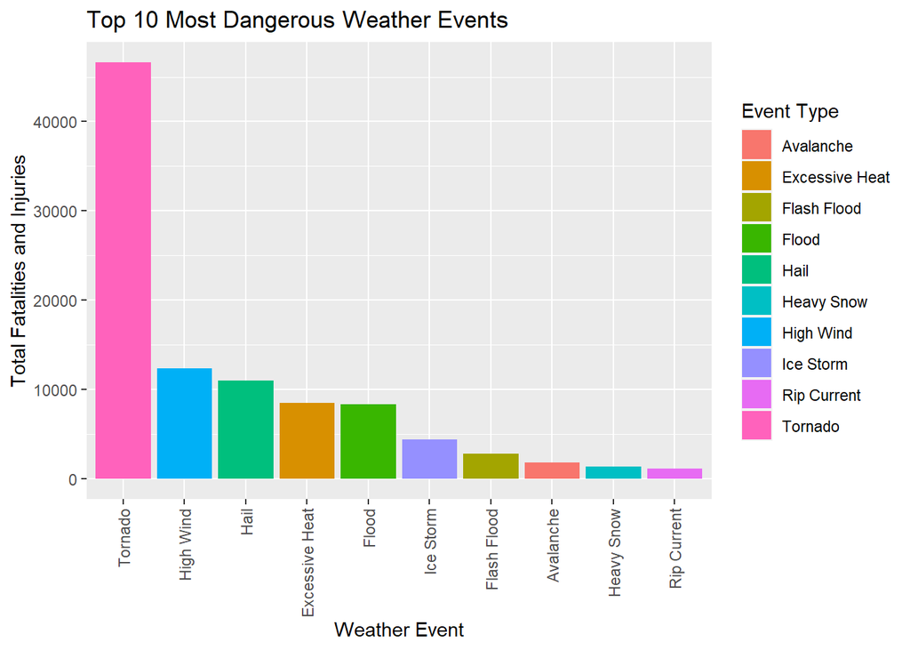

```r
healthData %>%
    group_by(EVENT) %>%
    summarize(dmg=sum(HEALTH.OUTCOMES)) %>%
    arrange(desc(dmg)) %>%
    top_n(10,dmg) %>% #Only grab top 10 most dangerous weather events
    ggplot(aes(x=reorder(EVENT,-dmg), #ensures we sort in descending order
               y=dmg,
               fill=EVENT)) +
        geom_bar(stat="identity") +
        theme(axis.text.x = element_text(angle=90,
                                         vjust=0.5,
                                         hjust=1)) +
        labs(x="Weather Event",
             y="Total Fatalities and Injuries",
             title="Top 10 Most Dangerous Weather Events") +
        scale_fill_discrete(name="Event Type")
```

### Economic Impacts

Next, we want to identify which types of events have the greatest economic consequences. To find this, we will us a bar plot to plot the total property damage and crop damage by event type. Once again, we’ll look at only the top 10 most damaging weather events.

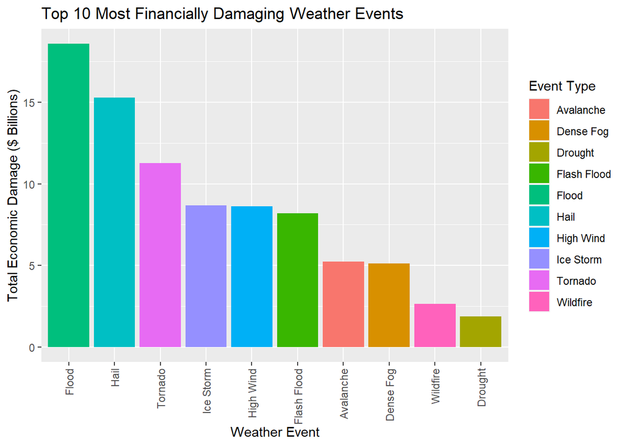

```r
economicData %>%
    group_by(EVENT) %>%
    summarize(dmg=sum(ECONOMIC.OUTCOMES)) %>%
    arrange(desc(dmg)) %>%
    top_n(10,dmg) %>% #Only grab top 10 most economically damaging weather events
    ggplot(aes(x=reorder(EVENT,-dmg),y=dmg,fill=EVENT)) + #ensures we sort in descending order
        geom_bar(stat="identity") +
        theme(axis.text.x = element_text(angle=90,
                                         vjust=0.5,
                                         hjust=1)) +
        labs(x="Weather Event",
             y="Total Economic Damage ($ Billions)",
             title="Top 10 Most Financially Damaging Weather Events") +
        scale_fill_discrete(name="Event Type")
```